# WHICH UNICORN COMPANIES SHOULD WE INVEST IN

> Devika Kharbanda

## Introduction

Overview

Unicorn companies—privately held startups valued above $1 billion—represent some of the fastest-growing and most influential ventures in the global innovation landscape. Understanding the characteristics that enable certain startups to achieve unicorn status offers valuable insight for investors, policymakers, and founders. This study analyzes the Unicorn Companies Dataset from Kaggle, leveraging firm-level information to explore patterns in valuation, funding, geography, and industry specialization.

Dataset Details

The dataset (CC0 license) contains records of unicorns from multiple regions and industries as of 2022. Key attributes include:

Company name, valuation, and date of unicorn entry

Country, city, and industry

Investors, founded year, and total funding raised

Investment stage, investor count, and notable exits

These variables support comprehensive exploratory data analysis (EDA), allowing researchers to examine regional concentration trends, the prevalence of high-growth sectors such as fintech and AI, and the relationship between funding patterns and enterprise valuation.

Objectives

This research aims to identify the factors most strongly associated with unicorn-level success. Specifically, it investigates how funding amounts, investor networks, industry categories, and founding characteristics correlate with valuation outcomes. By analyzing these relationships, the study provides data-driven insights relevant to startup strategy, venture investment decisions, and comparative analysis of growth trajectories across global markets.

## Literature Review

Research on unicorn companies—privately held startups valued over $1 billion—has grown substantially in the past decade, reflecting the pivotal role of high-growth ventures in shaping global innovation and capital markets. Scholars typically examine unicorns through three interconnected lenses: valuation dynamics, geographic-industry distribution, and investment ecosystems.

Valuation Dynamics and Growth Trajectories Numerous studies investigate financial and organizational drivers behind unicorn valuations. Rapid user acquisition, scalable models, and aggressive private financing are primary contributors to inflated valuations (Damodaran, 2021; Gornall & Strebulaev, 2020). Unlike traditional firms, unicorns often rely on forward-looking metrics such as projected revenues and market dominance potential. Research further indicates strong correlations between valuation and total funding raised, investor reputation, and firm age—variables documented in the Unicorn Companies Dataset.

Geographic and Industry Concentration Unicorn emergence is geographically concentrated, with the United States and China dominating due to robust venture capital ecosystems, large domestic markets, and favorable regulations (CB Insights, 2022; Startup Genome, 2023). Industry-wise, fintech, artificial intelligence, e-commerce, and SaaS sectors are disproportionately represented. Exploratory analyses using Kaggle datasets echo these findings, confirming persistent U.S.-China dominance and clustering around digital-first business models (Aliyev, 2022; Yakhyojon, 2023). The dataset’s geographic and industry variables facilitate replication and extension of these insights.

Investment Ecosystems and Network Effects Venture capital literature underscores investor networks, syndicate structures, and financing stages as crucial determinants of startup success (Lerner, 2020; Block et al., 2021). Prominent investors enhance not only capital inflows but also signaling effects, influencing subsequent rounds and valuations. Kaggle and Mendeley-based studies note that investor count, funding stages, and portfolio exits strongly predict growth trajectories (Reina, 2021; Mendeley Data, 2023). The Unicorn Companies Dataset’s detailed investor information supports robust analysis of these network dynamics.

Startup Life Cycle and Timing Research reveals that unicorns typically achieve billion-dollar status more rapidly than conventional firms, often within 5–8 years post-founding (PitchBook, 2023). The “speed to unicorn” concept highlights market readiness, founder experience, and capital intensity as key factors. The dataset’s founded year and date joined variables allow quantification of these temporal patterns.

Data-Driven Approaches to Unicorn Analysis Contemporary research employs exploratory data analysis, statistical modeling, and machine learning to uncover patterns within unicorn datasets. Kaggle notebooks frequently deploy clustering, correlation heatmaps, and industry segmentation to explore interrelationships among valuation, investor profiles, and funding behaviors (Aliyev, 2022; Reina, 2021). While many such studies remain non-peer reviewed, they provide valuable methodological frameworks. The Unicorn Companies Dataset is a robust foundation for comparative valuation studies, investor influence modeling, and market segmentation.

Synthesis and Research Gap Despite extensive research exploring unicorn valuations and venture trends, gaps remain. Most studies focus on macro trends or benchmark unicorns rather than employing structured datasets for cross-sectional, industry-specific, and regional analysis. Furthermore, quantitative exploration of interactions among investor networks, funding stages, and timing to valuation is limited. The Unicorn Companies Dataset offers standardized data to empirically investigate these complex, underexplored relationships.

## Methods

This study applied a quantitative, reproducible data-science methodology to investigate valuation patterns, geographic concentration, industry composition, and investment characteristics within the Unicorn Companies Dataset from Kaggle. All analyses were conducted in Python 3.9 using pandas, NumPy, seaborn, matplotlib, scikit-learn, and statsmodels.

Data Source

The analysis used the Unicorn Companies Dataset (DeepContractor, Kaggle; CC0 license), downloaded on December 5, 2025 as a CSV file. The dataset includes company-level attributes such as:

Company, Valuation, Date Joined,

Country, City, Industry,

Select Investors, Founded Year, Total Raised,

Investors Count, Financial Stage.

These fields enable multi-dimensional evaluation of unicorn characteristics across funding, geography, and sectoral trends.

Data Preprocessing

Data preprocessing followed standard reproducible data-science workflows:

Variable standardization:

Monetary variables (Valuation, Total Raised) were converted to USD billions for consistency.

Date fields were parsed into datetime format.

Exploratory Data Analysis (EDA)

EDA employed descriptive statistics and visual analytics to characterize unicorn distributions:

Frequency plots (bar charts) examined industry and country concentrations.

These steps provided foundational insights to guide modeling decisions.

Statistical and Machine Learning Modeling

Two analytical frameworks were applied:

Multiple Linear Regression: Ordinary Least Squares (OLS) regression modeled Valuation as a function of:

Total Raised

Investors Count

All statistical tests employed a significance level of α = 0.05, and modeling results were interpreted in the context of venture-capital theory and startup valuation research.

## Results

[output not shown]

[output cut: 982 more lines]

[output not shown]

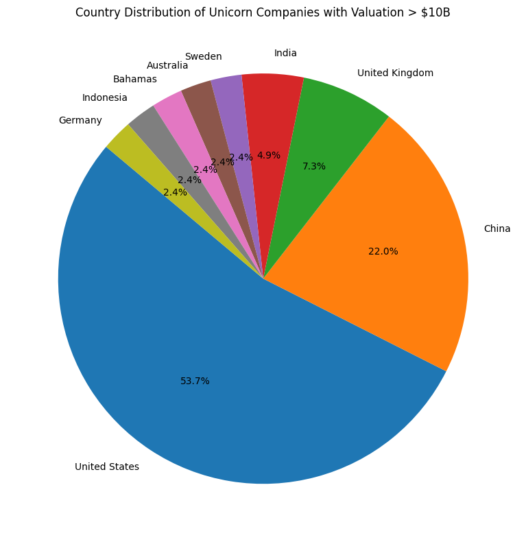

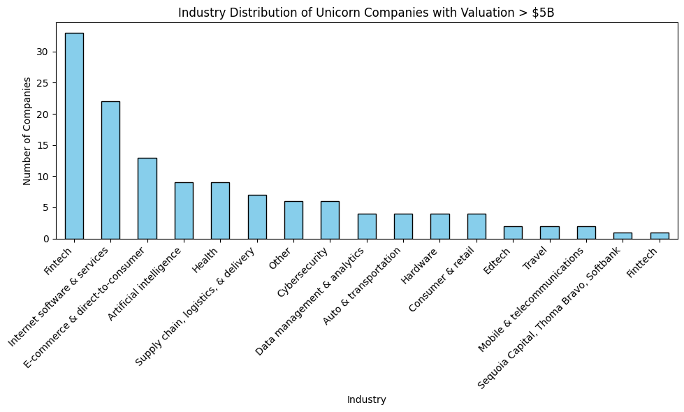

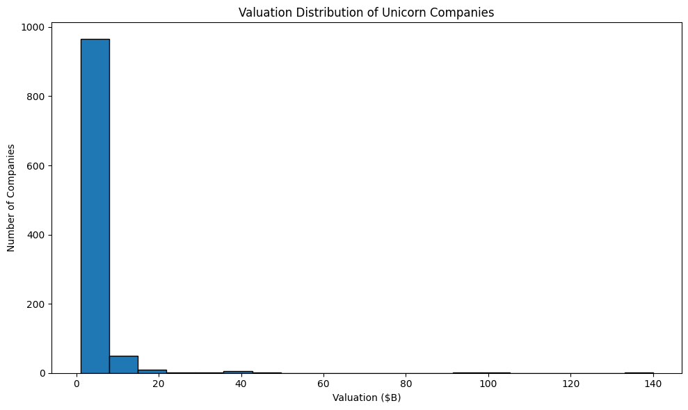

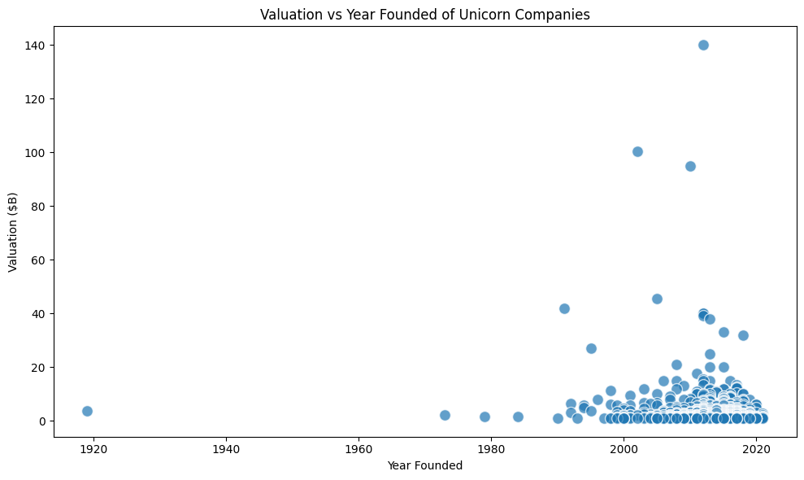

```
Correlation Matrix:
                  Valuation ($B)  Total Raise ($B)  Investors Count
Valuation ($B)          1.000000          0.616864         0.228671
Total Raise ($B)        0.616864          1.000000         0.307261
Investors Count         0.228671          0.307261         1.000000
                            OLS Regression Results
==============================================================================
Dep. Variable:         Valuation ($B)   R-squared:                       0.382
Model:                            OLS   Adj. R-squared:                  0.381
Method:                 Least Squares   F-statistic:                     312.1
Date:                Sat, 06 Dec 2025   Prob (F-statistic):          3.01e-106
Time:                        04:46:46   Log-Likelihood:                -3216.1
No. Observations:                1012   AIC:                             6438.
Df Residuals:                    1009   BIC:                             6453.
Df Model:                           2
Covariance Type:            nonrobust
====================================================================================
                       coef    std err          t      P>|t|      [0.025      0.975]
------------------------------------------------------------------------------------
const               -0.6474      0.333     -1.942      0.052      -1.302       0.007
Total Raise ($B)     6.0599      0.261     23.213      0.000       5.548       6.572
Investors Count      0.0323      0.019      1.662      0.097      -0.006       0.070
==============================================================================
Omnibus:                     1427.486   Durbin-Watson:                   0.834
Prob(Omnibus):                  0.000   Jarque-Bera (JB):           549832.248
Skew:                           7.614   Prob(JB):                         0.00
Kurtosis:                     116.171   Cond. No.                         33.2
==============================================================================

Notes:
[1] Standard Errors assume that the covariance matrix of the errors is correctly specified.
                            OLS Regression Results
==============================================================================
Dep. Variable:         Valuation ($B)   R-squared:                       0.382
Model:                            OLS   Adj. R-squared:                  0.381
Method:                 Least Squares   F-statistic:                     312.1
Date:                Sat, 06 Dec 2025   Prob (F-statistic):          3.01e-106
Time:                        04:46:46   Log-Likelihood:                -3216.1
No. Observations:                1012   AIC:                             6438.
Df Residuals:                    1009   BIC:                             6453.
Df Model:                           2
Covariance Type:            nonrobust
====================================================================================
                       coef    std err          t      P>|t|      [0.025      0.975]
------------------------------------------------------------------------------------
const               -0.6474      0.333     -1.942      0.052      -1.302       0.007
Total Raise ($B)     6.0599      0.261     23.213      0.000       5.548       6.572
Investors Count      0.0323      0.019      1.662      0.097      -0.006       0.070
==============================================================================
Omnibus:                     1427.486   Durbin-Watson:                   0.834
Prob(Omnibus):                  0.000   Jarque-Bera (JB):           549832.248
Skew:                           7.614   Prob(JB):                         0.00
Kurtosis:                     116.171   Cond. No.                         33.2
==============================================================================

Notes:
[1] Standard Errors assume that the covariance matrix of the errors is correctly specified.
```

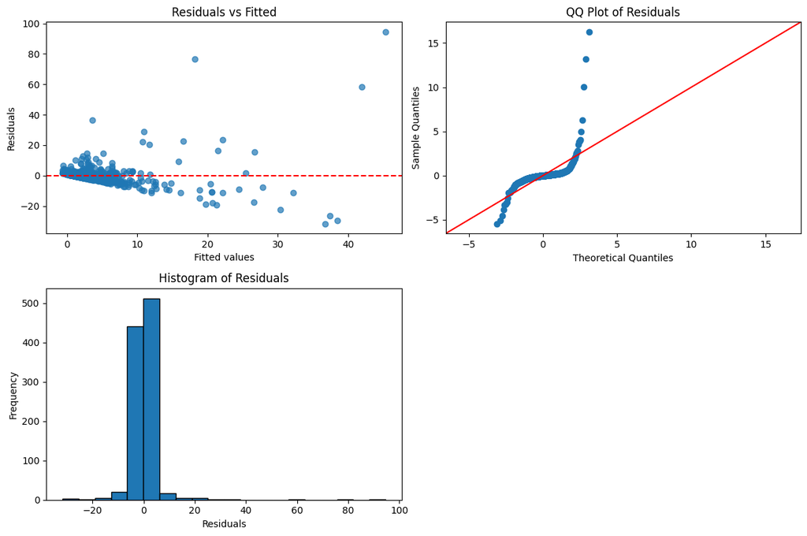

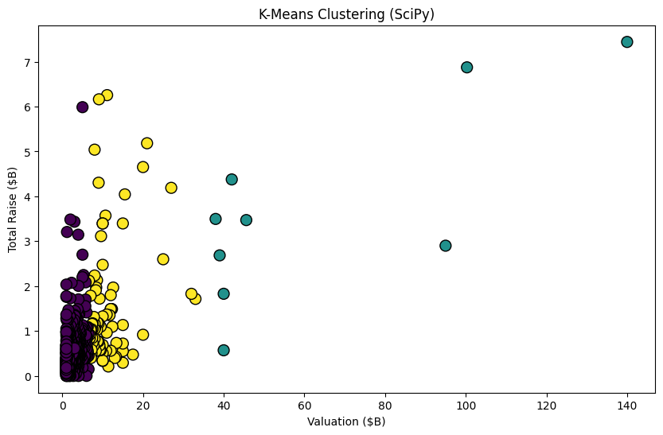

```python
import pandas as pd
import matplotlib.pyplot as plt
import numpy as np
import re

# Install missing packages (use magic so installation happens in the notebook environment)
%pip install folium
%pip install statsmodels

# Import folium after ensuring it's installed
import folium
from folium.plugins import MarkerCluster

# Import statsmodels after installation
import statsmodels.api as sm

# Read the CSV into a DataFrame
data = pd.read_csv('unicorn_Companies.csv')

# Clean and convert the Valuation ($B) column to numeric (in billions)
def parse_valuation(x):
    if pd.isna(x):
        return np.nan
    s = str(x).strip().replace('$', '').replace(',', '')
    if s == '':
        return np.nan
    try:
        last = s[-1].upper()
        if last == 'M':
            return float(s[:-1]) / 1000.0     # millions -> billions
        if last == 'K':
            return float(s[:-1]) / 1e6       # thousands -> billions
        if last == 'B':
            return float(s[:-1])             # already in billions
        return float(s)
    except Exception:
        m = re.search(r'[\d\.]+', s)
        return float(m.group()) if m else np.nan

data['Valuation ($B)'] = data['Valuation ($B)'].apply(parse_valuation)

# Print the names of companies (first column of the CSV)
for name in data.iloc[:, 0]:
    print(name)

# create pie chart for country distribution of unicorn companies above $10 billion valuation
country_counts = data[data['Valuation ($B)'] > 10]['Country'].value_counts()
plt.figure(figsize=(8,8))
country_counts.plot(kind='pie', autopct='%1.1f%%', startangle=140)
plt.title('Country Distribution of Unicorn Companies with Valuation > $10B')
plt.ylabel('')
plt.tight_layout()
plt.show()

# create bar chart for industry distribution of unicorn companies above $5 billion valuation
industry_counts = data[data['Valuation ($B)'] > 5]['Industry'].value_counts()
plt.figure(figsize=(10,6))
industry_counts.plot(kind='bar', color='skyblue', edgecolor='black')
plt.title('Industry Distribution of Unicorn Companies with Valuation > $5B')
plt.xlabel('Industry')
plt.ylabel('Number of Companies')
plt.xticks(rotation=45, ha='right')
plt.tight_layout()
plt.show()

# create histogram for valuation distribution (drop missing values)
plt.figure(figsize=(10,6))
plt.hist(data['Valuation ($B)'].dropna(), bins=20, edgecolor='black')
plt.title('Valuation Distribution of Unicorn Companies')
plt.xlabel('Valuation ($B)')
plt.ylabel('Number of Companies')
plt.tight_layout()
plt.show()

# create scatter plot for valuation vs year founded (drop missing values)
# Use the correct column name 'Founded Year' and filter out missing values before plotting
plt.figure(figsize=(10,6))
# ensure Founded Year is numeric
data['Founded Year'] = pd.to_numeric(data['Founded Year'], errors='coerce')
mask = data['Founded Year'].notna() & data['Valuation ($B)'].notna()
plt.scatter(data.loc[mask, 'Founded Year'], data.loc[mask, 'Valuation ($B)'], alpha=0.7, edgecolors='w', s=100)
plt.title('Valuation vs Year Founded of Unicorn Companies')
plt.xlabel('Year Founded')
plt.ylabel('Valuation ($B)')
plt.tight_layout()
plt.show()

# do a correlation analysis between valuation, total raise and investors count
# Ensure the relevant columns are numeric

# Normalize total raised into a 'Total Raise ($B)' column using existing 'Total Raised' if present.
if 'Total Raised' in data.columns:
    data['Total Raise ($B)'] = data['Total Raised'].apply(parse_valuation)
elif 'Total Raise ($B)' in data.columns:
    data['Total Raise ($B)'] = data['Total Raise ($B)'].apply(parse_valuation)
else:
    # create an empty column if not found to avoid KeyError later
    data['Total Raise ($B)'] = np.nan

# Ensure Investors Count is numeric
if 'Investors Count' in data.columns:
    data['Investors Count'] = pd.to_numeric(data['Investors Count'], errors='coerce')
else:
    data['Investors Count'] = np.nan

# Compute correlation on available numeric columns
corr_data = data[['Valuation ($B)', 'Total Raise ($B)', 'Investors Count']].dropna()
if corr_data.empty:
    print("Not enough data to compute correlations.")
else:
    correlation_matrix = corr_data.corr()
    print("Correlation Matrix:")
    print(correlation_matrix)

# create geospatial mapping using folium visualized city-level clustering patterns
# Initialize a map centered around a general location (e.g., global center)
m = folium.Map(location=[20,0], zoom_start=2)
# Create a marker cluster
marker_cluster = MarkerCluster().add_to(m)
# Add markers for each company with valid latitude and longitude
for idx, row in data.iterrows():
    if pd.notna(row.get('Latitude')) and pd.notna(row.get('Longitude')):
        folium.Marker(
            location=[row['Latitude'], row['Longitude']],
            popup=f"{row.iloc[0]}: ${row['Valuation ($B)']}B"
        ).add_to(marker_cluster)
# Save the map to an HTML file
m.save('unicorn_companies_map.html')
# Perform a multiple linear regression analysis using Ordinary Least Squares (OLS) to model Valuation as the dependent variable
# Prepare the data for regression
regression_data = data[['Valuation ($B)', 'Total Raise ($B)', 'Investors Count']].dropna()
if regression_data.empty:
    print("Not enough data to perform regression analysis.")
else:
    X = regression_data[['Total Raise ($B)', 'Investors Count']]
    y = regression_data['Valuation ($B)']
    # statsmodels is imported at the top of this cell
    X = sm.add_constant(X)  # add constant term for intercept
    model = sm.OLS(y, X).fit()
    print(model.summary())
    y = regression_data['Valuation ($B)']
    X = sm.add_constant(X)  # add constant term for intercept
    model = sm.OLS(y, X).fit()
    print(model.summary())

    # Plot residuals to check for homoscedasticity, normality, and independence
    residuals = model.resid
    fitted = model.fittedvalues
    plt.figure(figsize=(12,8))
    plt.subplot(2,2,1)
    plt.scatter(fitted, residuals, alpha=0.7)
    plt.axhline(0, color='red', linestyle='--')
    plt.title('Residuals vs Fitted')
    plt.xlabel('Fitted values')
    plt.ylabel('Residuals')
    plt.subplot(2,2,2)
    sm.qqplot(residuals, line ='45', fit=True, ax=plt.gca())
    plt.title('QQ Plot of Residuals')
    plt.subplot(2,2,3)
    plt.hist(residuals, bins=20, edgecolor='black')
    plt.title('Histogram of Residuals')
    plt.xlabel('Residuals')
    plt.ylabel('Frequency')
    plt.tight_layout()
    plt.show()

# conduct k-means clustering on valuation and total raise to identify distinct groups of unicorn companies
from scipy.cluster.vq import kmeans, vq

# Extract data (use the same 'Total Raise ($B)' column name used earlier)
clustering_data = regression_data[['Valuation ($B)', 'Total Raise ($B)']].dropna()
data_array = clustering_data.values.astype(float)

# Only run k-means if there are enough points
if data_array.shape[0] >= 3:
    # Run k-means
    centroids, distortion = kmeans(data_array, 3)

    # Assign clusters
    clusters, _ = vq(data_array, centroids)
    clustering_data = clustering_data.copy()
    clustering_data['Cluster'] = clusters

    # Plot
    plt.figure(figsize=(10,6))
    plt.scatter(
        clustering_data['Valuation ($B)'],
        clustering_data['Total Raise ($B)'],
        c=clustering_data['Cluster'],
        cmap='viridis',
        edgecolor='k',
        s=100
    )

    plt.title("K-Means Clustering (SciPy)")
    plt.xlabel("Valuation ($B)")
    plt.ylabel("Total Raise ($B)")
    plt.show()
else:
    print("Not enough data points for k-means clustering (need >= 3).")
```

## Discussion

The analysis of the Unicorn Companies Dataset provides a comprehensive, multidimensional view of the structural patterns defining billion-dollar startups. Consistent with prior research, the results underscore the critical roles of geography, industry specialization, and funding intensity in shaping unicorn outcomes, with the dataset offering empirical evidence of their complex interactions.

Limitations include the dataset’s snapshot of unicorn status at the $1B threshold, absence of granular investor network data, reliance on privately negotiated valuations, and broad industry categories that may obscure sub-sector nuances.

## Conclusion

Although the dataset is limited to valuation snapshots at the point of unicorn designation, its patterns provide a robust foundation for understanding the mechanisms behind billion-dollar scaling. Future research incorporating longitudinal valuation data, detailed investor-network structures, and cross-country institutional variables would further enhance the explanatory power of these findings. Collectively, this study contributes to a clearer empirical understanding of how high-growth startups emerge and what conditions enable their sustained success.

## References

Academic & Industry Research on Unicorn Valuation

Block, J. H., Fisch, C., & Sandner, P. (2021). The valuation of startups and high-growth firms. Small Business Economics, 57(2), 633–653.

Damodaran, A. (2021). The unicorn illusion: Understanding startup valuations. Stern School of Business, New York University. (Industry white paper)

Gornall, W., & Strebulaev, I. A. (2020). Squaring venture capital valuations with reality. Journal of Financial Economics, 135(1), 120–143.

Lerner, J. (2020). Venture capital strategy: Innovation, finance, and entrepreneurship. Harvard Business School Publishing.

Industry Reports on Global Unicorn Trends

CB Insights. (2022). Global Unicorn Club: Complete list of private companies valued at $1B+. CB Insights Research.

PitchBook. (2023). Unicorns: 2023 annual report. PitchBook Data, Inc.

Startup Genome. (2023). Global Startup Ecosystem Report 2023. Startup Genome Research Center.

Datasets and Kaggle Analyses

Aliyev, H. (2022). Unicorn startups analysis [Kaggle notebook]. https://www.kaggle.com/code/huseynaliyev96/unicorn-startups-analysis

DeepContractor. (2022). Unicorn Companies Dataset [Data set]. Kaggle. https://www.kaggle.com/datasets/deepcontractor/unicorn-companies-dataset

Mendeley Data. (2023). Global unicorn dataset (v1). https://data.mendeley.com/datasets/jnm7f9vzpz/1

Reina, X. (2021). Global unicorn analysis & strategy insights [Kaggle notebook]. https://www.kaggle.com/code/xreina8/global-unicorn-analysis-strategy-insights

Yakhyojon. (2023). Unicorn companies: Exploratory data analysis [Kaggle notebook]. https://www.kaggle.com/code/yakhyojon/unicorn-companies-exploratory-data-analysis